# group1_census

## `Abstract`

`This classification project focuses on predicting individuals' income, age (bucketed and with groups), and marital status using census data. The dataset consists of various demographic characteristics, including work class, education, marital status, occupation, relationship status, race, sex, and native country. The two main tasks undertaken involve binary classification (predicting if an individual's income is above or below 50K) and regression (predicting the age of the individual).`

`In preparing the data for machine learning models, we employed data imputation strategies to handle missing values, replacing them with the mean or common values of the corresponding columns. Categorical variables were transformed into vectorized representations using StringIndexer and OneHotEncoder to suit the machine learning algorithms' needs.`

`The machine learning models used for the binary classification task included logistic regression. Logistic regression yielded an accuracy of ~85%, indicating a strong performance.`

`Overall, the project has highlighted the complexities involved in demographic prediction tasks and offered some potential pathways for future exploration. Future work could consider incorporating more granular income data or additional demographic variables to enhance the regression model's performance.`

`This work provides a baseline for using census data to predict personal characteristics and suggests further exploration in feature engineering and selection, as well as other machine learning models.`

### Load the required libraries

```python
import nltk
from umap import UMAP
import pandas as pd
import matplotlib.pyplot as plt
import numpy as np
import seaborn as sns

from pyspark.sql import functions as F
from pyspark.sql.functions import when, col, lit
from pyspark.ml.feature import (
    Bucketizer,
    OneHotEncoder,
    StringIndexer,
    SQLTransformer
)
from pyspark.ml import Pipeline
from pyspark.ml.classification import (
    LogisticRegression,
    RandomForestClassifier,
    GBTClassifier
)
from pyspark.ml.evaluation import (
    BinaryClassificationEvaluator,
    MulticlassClassificationEvaluator,
    RegressionEvaluator,
)
from pyspark.ml.tuning import CrossValidator, ParamGridBuilder
from pyspark.ml.feature import (
    StringIndexer,
    VectorAssembler,
    StandardScaler,
    IndexToString
)
from pyspark.ml.regression import RandomForestRegressor
from pyspark.mllib.evaluation import (
    BinaryClassificationMetrics,
    MulticlassMetrics,
)

from pyspark.ml.stat import Correlation
from pyspark.sql import SparkSession
import logging

# Create Spark session
spark = SparkSession.builder\
    .appName("census_data") \
    .getOrCreate()

# Set the logging level to ERROR/FATAL
spark.sparkContext.setLogLevel("FATAL")
logger = logging.getLogger("py4j")
logger.setLevel(logging.CRITICAL)
nltk.download('wordnet', quiet=True)
```

```
True
```

### Load the data

```python
raw_data = spark.read.csv(
    "adult.csv",
    escape='"',
    header=True,
    inferSchema=True,
)

data = raw_data
```

### Explore the data

Doing some basic exploration of the data to start understanding the data and what it looks like.

```python
print("Data schema:")
data.printSchema()
print("\nData row sample:")
data.show(10)
print(f"\nNumber of rows in data: {data.count()}")
print(f"Number of columns in data: {len(data.columns)}")
machine_names = [
    'workclass',
    'education',
    'marital-status',
    'occupation',
    'relationship',
    'race',
    'native-country',
    'income'
]
for name in machine_names:
    print(f"\n{name} column value counts:")
    data.groupBy(name).count().show()
```

```
Data schema:
root
 |-- age: integer (nullable = true)
 |-- workclass: string (nullable = true)
 |-- fnlwgt: integer (nullable = true)
 |-- education: string (nullable = true)
 |-- educational-num: integer (nullable = true)
 |-- marital-status: string (nullable = true)
 |-- occupation: string (nullable = true)
 |-- relationship: string (nullable = true)
 |-- race: string (nullable = true)
 |-- gender: string (nullable = true)
 |-- capital-gain: integer (nullable = true)
 |-- capital-loss: integer (nullable = true)
 |-- hours-per-week: integer (nullable = true)
 |-- native-country: string (nullable = true)
 |-- income: string (nullable = true)


Data row sample:
+---+----------------+------+------------+---------------+------------------+-----------------+-------------+-----+------+------------+------------+--------------+--------------+------+
|age|       workclass|fnlwgt|   education|educational-num|    marital-status|       occupation| relationship| race|gender|capital-gain|capital-loss|hours-per-week|native-country|income|
+---+----------------+------+------------+---------------+------------------+-----------------+-------------+-----+------+------------+------------+--------------+--------------+------+
| 25|         Private|226802|        11th|              7|     Never-married|Machine-op-inspct|    Own-child|Black|  Male|           0|           0|            40| United-States| <=50K|
| 38|         Private| 89814|     HS-grad|              9|Married-civ-spouse|  Farming-fishing|      Husband|White|  Male|           0|           0|            50| United-States| <=50K|
| 28|       Local-gov|336951|  Assoc-acdm|             12|Married-civ-spouse|  Protective-serv|      Husband|White|  Male|           0|           0|            40| United-States|  >50K|
| 44|         Private|160323|Some-college|             10|Married-civ-spouse|Machine-op-inspct|      Husband|Black|  Male|        7688|           0|            40| United-States|  >50K|
| 18|               ?|103497|Some-college|             10|     Never-married|                ?|    Own-child|White|Female|           0|           0|            30| United-States| <=50K|
| 34|         Private|198693|        10th|              6|     Never-married|    Other-service|Not-in-family|White|  Male|           0|           0|            30| United-States| <=50K|
| 29|               ?|227026|     HS-grad|              9|     Never-married|                ?|    Unmarried|Black|  Male|           0|           0|            40| United-States| <=50K|
| 63|Self-emp-not-inc|104626| Prof-school|             15|Married-civ-spouse|   Prof-specialty|      Husband|White|  Male|        3103|           0|            32| United-States|  >50K|
| 24|         Private|369667|Some-college|             10|     Never-married|    Other-service|    Unmarried|White|Female|           0|           0|            40| United-States| <=50K|
| 55|         Private|104996|     7th-8th|              4|Married-civ-spouse|     Craft-repair|      Husband|White|  Male|           0|           0|            10| United-States| <=50K|
+---+----------------+------+------------+---------------+------------------+-----------------+-------------+-----+------+------------+------------+--------------+--------------+------+
only showing top 10 rows


Number of rows in data: 48842
Number of columns in data: 15

```

[output cut: 111 more lines]

```
|         Nicaragua|   49|
|              Hong|   30|
|              Peru|   46|
|             India|  151|
|             China|  122|
|             Italy|  105|
|Holand-Netherlands|    1|
|              Cuba|  138|
|             South|  115|
|              Iran|   59|
|           Ireland|   37|
|          Thailand|   30|
|              Laos|   23|
+------------------+-----+
only showing top 20 rows
```

### Clean the data using imputations

The assumption here is that ? represents missing data in the dataset. The choice to replace with the mode (for categorical columns) and mean (for numerical columns) is based on a heuristic that often works well.

```python
categorical_cols = ['workclass', 'education', 'marital-status', 'occupation', 'relationship', 'race', 'native-country']
numerical_cols = ['age', 'fnlwgt', 'educational-num', 'capital-gain', 'capital-loss', 'hours-per-week']

# Replace ? with the mode for categorical columns
for col_name in categorical_cols:
    mode = data.filter(data[col_name] != '?').groupBy(col_name).count().orderBy('count', ascending=False).first()[0]
    data = data.withColumn(col_name, when(col(col_name) == '?', mode).otherwise(col(col_name)))

# Replace ? with the mean for numerical columns
for col_name in numerical_cols:
    mean_value = data.filter(data[col_name] != '?').select(col_name).agg({col_name: 'mean'}).first()[0]
    data = data.withColumn(col_name, when(col(col_name) == '?', mean_value).otherwise(col(col_name)))
```

## => `Predict Income exercise`

As the income data is binary, we expect to use some regression model to predict income using all columns(except income) as features and the income column as our target variable.

Using `LogisticRegression` for income prediction seems appropriate when categorizing individuals into distinct income groups based on their demographic features, providing probabilities and insights into how each feature influences the likelihood of falling into a specific income category.

### Feature Engineering

In order to use LogisticRegression, we need to turn categorical variables into vectorized representations to be used for training.

```python
indexers = [StringIndexer(inputCol=col, outputCol=f"{col}_index") for col in categorical_cols]
encoders = [OneHotEncoder(inputCol=f"{col}_index", outputCol=f"{col}_vec") for col in categorical_cols]

pipeline = Pipeline(stages=indexers + encoders)
data = pipeline.fit(data).transform(data)
```

### Train the model

The train will use 80% of the available data and will use all features to the model and see how it performs in predicting income.

```python
train_data, test_data = data.randomSplit([0.8, 0.2], seed=42)

target_indexer = StringIndexer(inputCol='income', outputCol='label')
target_indexer_model = target_indexer.fit(train_data)
train_data = target_indexer_model.transform(train_data)

features = [f"{col}_vec" for col in categorical_cols] + numerical_cols
assembler = VectorAssembler(inputCols=features, outputCol="features")

lr = LogisticRegression(featuresCol='features', labelCol='label')

pipeline = Pipeline(stages=[assembler, lr])
model = pipeline.fit(train_data)
```

### Use Logistic Regression algorithm

```python
# Index the categorical target column income to numerical labels named label.
target_indexer = StringIndexer(inputCol='income', outputCol='label')

# Checking here to see already exists in train_data, if so, drop it.
# might just been specific to issues becasue of the way the data was loaded.
if 'label' in train_data.columns:
    train_data = train_data.drop('label')

# Fit the target_indexer on the train_data and transform it
target_indexer_model = target_indexer.fit(train_data)
train_data = target_indexer_model.transform(train_data)

# Prepare the feature columns for vectorization
features = [f"{col}_vec" for col in categorical_cols] + numerical_cols

# Assemble the features into a single vector column named features
assembler = VectorAssembler(inputCols=features, outputCol="features")

# Create a logistic regression classifier
lr = LogisticRegression(featuresCol='features', labelCol='label')

# Create a pipeline with the assembler and logistic regression stages
pipeline = Pipeline(stages=[assembler, lr])

# Fit the pipeline on the train_data to train the logistic regression model
model = pipeline.fit(train_data)

# Same as above.
if 'label' in test_data.columns:
    test_data = test_data.drop('label')

# Transform the test_data using the trained target_indexer_model
test_data = target_indexer_model.transform(test_data)

# Make predictions on test_data using the trained model
predictions = model.transform(test_data)

# Evaluate the model's performance on test data using accuracy metric
evaluator = MulticlassClassificationEvaluator(labelCol="label", predictionCol="prediction")
accuracy = evaluator.evaluate(predictions, {evaluator.metricName: "accuracy"})

# Convert DataFrame to RDD and prepare for BinaryClassificationMetrics
predictionAndLabels = predictions.select("prediction", "label").rdd.map(lambda r: (float(r[0]), float(r[1])))

# Instantiate metrics object for binary classification
metrics = BinaryClassificationMetrics(predictionAndLabels)

# Calculate precision, recall, and F1 score
precision = metrics.areaUnderPR
recall = metrics.areaUnderROC
f1Score = 2 * (precision * recall) / (precision + recall) if (precision + recall) > 0 else 0

# Evaluate Area Under ROC
binary_evaluator = BinaryClassificationEvaluator(rawPredictionCol="rawPrediction", labelCol="label", metricName="areaUnderROC")
auc_roc = binary_evaluator.evaluate(predictions)

# Evaluate Area Under PR
binary_evaluator.setMetricName("areaUnderPR")
auc_pr = binary_evaluator.evaluate(predictions)

# Print the evaluation metrics
print(f"Accuracy = {accuracy}")
print(f"Precision = {precision}")
print(f"Recall = {recall}")
print(f"F1 Score = {f1Score}")
print(f"Area Under ROC: {auc_roc}")
print(f"Area Under PR: {auc_pr}")
```

```
Accuracy = 0.8484442612816815
Precision = 0.6315601305232993
Recall = 0.7613199651631117
F1 Score = 0.6903958755063706
Area Under ROC: 0.9001652520540463
Area Under PR: 0.7619117357530435
```

### Visualize distribution of feature embeddings

Because we expect for >50K income samples to be clustered closer together and further from <50K samples, we will use Uniform Manifold Approximation and Projection (or UMAP) is a new dimension reduction technique that can be used to visualize patterns of clustering in high-dimensional data.

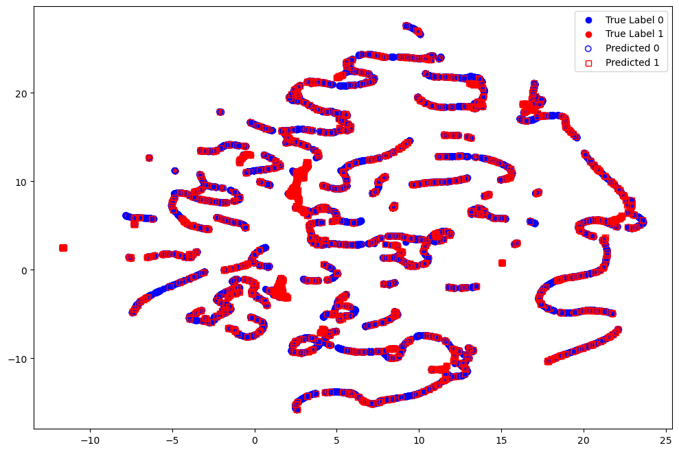

```python
features_local = predictions.rdd.map(lambda row: row.features.toArray().tolist()).collect()

reduced_data = UMAP(n_neighbors=15, min_dist=0.1, n_components=2).fit_transform(features_local)
reduced_df = pd.DataFrame(reduced_data, columns=["UMAP1", "UMAP2"])


predictions_local = predictions.select("prediction").toPandas()
labels_local = predictions.select("label").toPandas()

reduced_df['prediction'] = predictions_local
reduced_df['true_label'] = labels_local

plt.figure(figsize=(12,8))
plt.scatter(reduced_df[reduced_df.true_label == 0].UMAP1, reduced_df[reduced_df.true_label == 0].UMAP2, c='blue', label='True Label 0')
plt.scatter(reduced_df[reduced_df.true_label == 1].UMAP1, reduced_df[reduced_df.true_label == 1].UMAP2, c='red', label='True Label 1')
plt.scatter(reduced_df[reduced_df.prediction == 0].UMAP1, reduced_df[reduced_df.prediction == 0].UMAP2, c='none', edgecolor='blue', marker='o', label='Predicted 0')
plt.scatter(reduced_df[reduced_df.prediction == 1].UMAP1, reduced_df[reduced_df.prediction == 1].UMAP2, c='none', edgecolor='red', marker='s', label='Predicted 1')
plt.legend()
plt.show()
```

### Observe Prediction Accuracy Visualization and Incorrect predictions in a Histogram

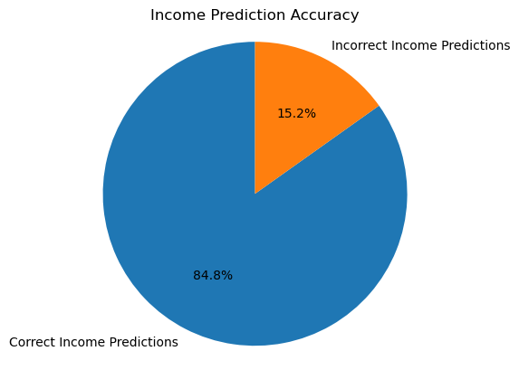

```python
predictions_pd = predictions.toPandas()

correct_predictions = sum(predictions_pd['label'] == predictions_pd['prediction'])
incorrect_predictions = sum(predictions_pd['label'] != predictions_pd['prediction'])

labels = ['Correct Income Predictions', 'Incorrect Income Predictions']
sizes = [correct_predictions, incorrect_predictions]
fig1, ax1 = plt.subplots()
ax1.pie(sizes, labels=labels, autopct='%1.1f%%', startangle=90)
ax1.axis('equal')
plt.title('Income Prediction Accuracy')
plt.show()
```

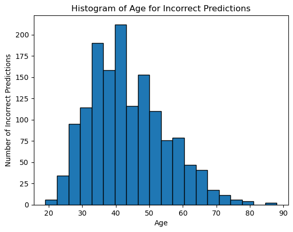

```python
# Filter the dataframe to include only incorrectly predicted instances
incorrect_predictions = predictions_pd[predictions_pd['label'] != predictions_pd['prediction']]
plt.hist(incorrect_predictions['age'], bins=20, edgecolor='black')
plt.title('Histogram of Age for Incorrect Predictions')
plt.xlabel('Age')
plt.ylabel('Number of Incorrect Predictions')
plt.show()
```

### Observe income predictions in a Confusion Matrix

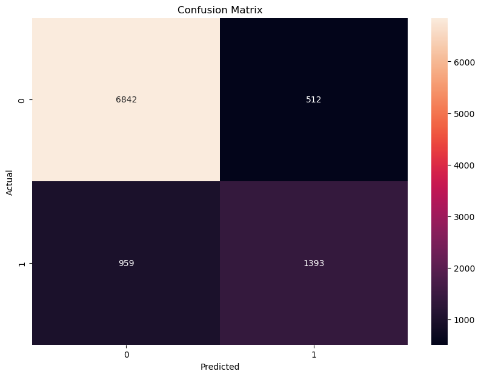

```python
# MulticlassMetrics object to compute metrics based on predictions and labels,
metrics = MulticlassMetrics(predictions.select('prediction', 'label').rdd)

confusion_matrix = metrics.confusionMatrix().toArray()

plt.figure(figsize=(10, 7))
sns.heatmap(confusion_matrix, annot=True, fmt=".0f")
plt.xlabel('Predicted')
plt.ylabel('Actual')
plt.title("Confusion Matrix")
plt.show()
```

### Observe income predictions in a Heat Map for correlations

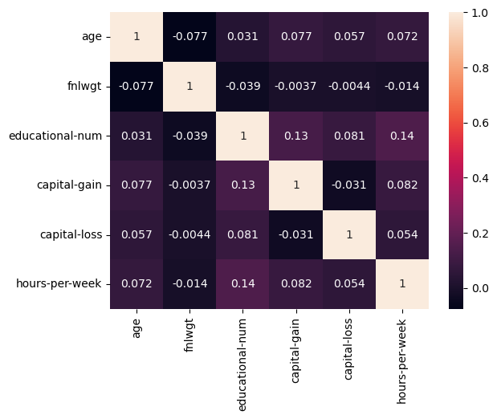

```python
# Only numeric columns.
numeric_data = data.select(numerical_cols)
data_pd = numeric_data.toPandas()

corr_matrix = data_pd.corr()

sns.heatmap(corr_matrix, annot=True)
plt.show()
```

`The low correlation could result in a low prediction capability if we use target variables with high cardinality or that represent multi-class data.`

`Let's use the Age feature(high cardinality and multi-class) as our next target variable...`

### => `Some statistic regarding Age`

```python
data_num = data.drop("educational-num","income")
data_num.describe("age").show()
```

```
+-------+------------------+
|summary|               age|
+-------+------------------+
|  count|             48842|
|   mean| 38.64358543876172|
| stddev|13.710509934443518|
|    min|                17|
|    max|                90|
+-------+------------------+
```

`Observing the data, especially the variability of our target variable(age): The age column has a standard deviation (std) of approximately 13.71, which means the age values have significant variability. This spread could make the prediction task more challenging than if most individuals were around the same age.`

`Features like capital_gain and capital_loss are heavily skewed with most values at 0 but with high max values. This skewness might make these features less informative for age prediction unless certain capital gains or losses are specifically associated with particular age groups.`

`The distribution of the age column itself, ranging from 17 to 90 with a mean of 38.64, shows a broad range of ages. Predicting age as a regression problem over this range could be harder than, say, classifying individuals into age groups (e.g., young, middle-aged, elderly).`

`It makes sense to approach this prediction as a regression, at minimum because of the flexibility of features, since regression models can effectively handle a mix of categorical and continuous features, which is common in datasets that might be used to predict age. This allows for a broad set of data to be used without requiring extensive transformations.`

```python
# The features column reused, remove age from numerical_cols.
new_numerical_cols = [col for col in numerical_cols if col != 'age']

new_features = [f"{col}_vec" for col in categorical_cols] + new_numerical_cols
new_assembler = VectorAssembler(inputCols=new_features, outputCol="new_features")

# Random Forest Regressor.
rf = RandomForestRegressor(featuresCol='new_features', labelCol='age')

new_pipeline = Pipeline(stages=[new_assembler, rf])

# Fit the model.
new_model = new_pipeline.fit(train_data)

# Transform the test data.
predictions = new_model.transform(test_data)

# Root Mean Squared Error.
evaluator = RegressionEvaluator(labelCol="age", predictionCol="prediction", metricName="rmse")
rmse = evaluator.evaluate(predictions)
print(f"Root Mean Squared Error = {rmse}")

# Mean Absolute Error.
evaluator = RegressionEvaluator(labelCol="age", predictionCol="prediction", metricName="mae")
mae = evaluator.evaluate(predictions)
print(f"Mean Absolute Error = {mae}")

# R-Squared.
evaluator = RegressionEvaluator(labelCol="age", predictionCol="prediction", metricName="r2")
r2 = evaluator.evaluate(predictions)
print(f"R-Squared = {r2}")
```

```
Root Mean Squared Error = 10.414864683236182
Mean Absolute Error = 8.162488582386278
R-Squared = 0.41127973095556125
```

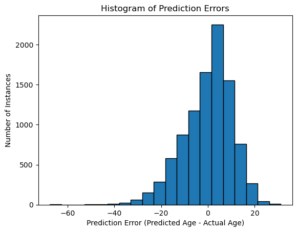

```python
predictions_pd = predictions.toPandas()
predictions_pd['error'] = predictions_pd['prediction'] - predictions_pd['age']

plt.hist(predictions_pd['error'], bins=20,edgecolor='black')
plt.title('Histogram of Prediction Errors')
plt.xlabel('Prediction Error (Predicted Age - Actual Age)')
plt.ylabel('Number of Instances')
plt.show()
```

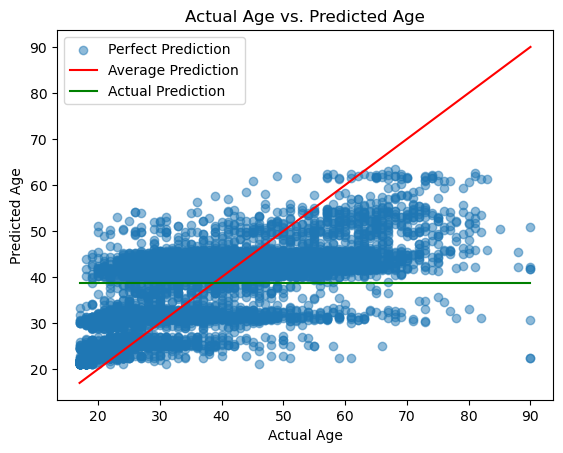

```
Number of unique predictions: 2086
Unique predictions: [22.02425057 21.55398259 21.73668461 ... 34.65175282 54.38437146
 50.43408467]
```

```python
# actual age vs. predicted age
plt.scatter(predictions_pd['age'], predictions_pd['prediction'], alpha=0.5)
plt.title('Actual Age vs. Predicted Age')
plt.xlabel('Actual Age')
plt.ylabel('Predicted Age')

# Line representing perfect prediction
perfect_range = np.linspace(min(predictions_pd['age']), max(predictions_pd['age']), num=500)
plt.plot(perfect_range, perfect_range, color='red')

# Plotting the average prediction
mean_pred = np.mean(predictions_pd['prediction'])
plt.plot(perfect_range, [mean_pred]*500, color='green')

plt.legend(['Perfect Prediction', 'Average Prediction', 'Actual Prediction'])
plt.show()
unique_predictions = predictions_pd['prediction'].unique()
print(f"Number of unique predictions: {len(unique_predictions)}")
print(f"Unique predictions: {unique_predictions}")
```

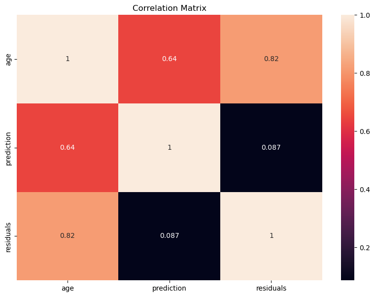

```python
predictions_pd = predictions.select("age", "prediction").toPandas()

predictions_pd["residuals"] = predictions_pd["age"] - predictions_pd["prediction"]
correlation_matrix = predictions_pd.corr()
plt.figure(figsize=(10, 7))
sns.heatmap(correlation_matrix, annot=True)
plt.title("Correlation Matrix")
plt.show()
```

### Age Prediction Correlation Matrix

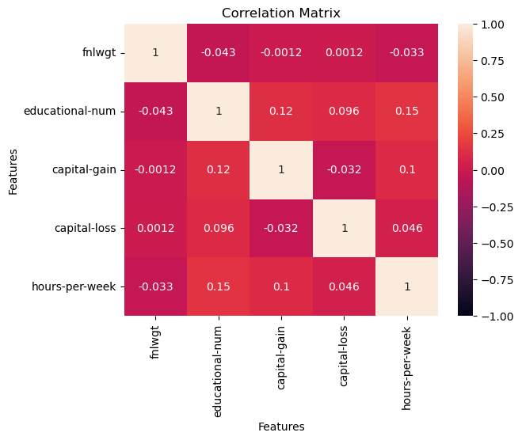

```python
numeric_test_data = test_data.select(new_numerical_cols)
numeric_test_data_pd = numeric_test_data.toPandas()
corr_matrix = numeric_test_data_pd.corr()

sns.heatmap(corr_matrix, annot=True, vmin=-1, vmax=1)
plt.xlabel("Features")
plt.ylabel("Features")
plt.title("Correlation Matrix")
plt.show()
```

`Let's see if we can get a better prediction by using ages in buckets...`

### Random Forest Classifier with Ages bucketed

```python
# splits for age buckets
splits = [-float("inf"), 20, 30, 40, 50, 60, 70, 80, float("inf")]
bucketizer = Bucketizer(splits=splits, inputCol="age", outputCol="age_bucket")

# Add to the data.
data = bucketizer.setHandleInvalid("keep").transform(data)

# Split the data again.
train_data, test_data = data.randomSplit([0.8, 0.2], seed=42)

data.printSchema()
```

```
root
 |-- age: integer (nullable = true)
 |-- workclass: string (nullable = true)
 |-- fnlwgt: integer (nullable = true)
 |-- education: string (nullable = true)
 |-- educational-num: integer (nullable = true)
 |-- marital-status: string (nullable = true)
 |-- occupation: string (nullable = true)
 |-- relationship: string (nullable = true)
 |-- race: string (nullable = true)
 |-- gender: string (nullable = true)
 |-- capital-gain: integer (nullable = true)
 |-- capital-loss: integer (nullable = true)
 |-- hours-per-week: integer (nullable = true)
 |-- native-country: string (nullable = true)
 |-- income: string (nullable = true)
 |-- workclass_index: double (nullable = false)
 |-- education_index: double (nullable = false)
 |-- marital-status_index: double (nullable = false)
 |-- occupation_index: double (nullable = false)
 |-- relationship_index: double (nullable = false)
 |-- race_index: double (nullable = false)
 |-- native-country_index: double (nullable = false)
 |-- workclass_vec: vector (nullable = true)
 |-- education_vec: vector (nullable = true)
 |-- marital-status_vec: vector (nullable = true)
 |-- occupation_vec: vector (nullable = true)
 |-- relationship_vec: vector (nullable = true)
 |-- race_vec: vector (nullable = true)
 |-- native-country_vec: vector (nullable = true)
 |-- age_bucket: double (nullable = true)
```

```python
# remove age
new_numerical_cols = [col for col in numerical_cols if col != 'age']

new_features = [f"{col}_vec" for col in categorical_cols] + new_numerical_cols
new_assembler = VectorAssembler(inputCols=new_features, outputCol="new_features")

# RandomForestClassifier
rf = RandomForestClassifier(featuresCol='new_features', labelCol='age_bucket', numTrees=100)

new_pipeline = Pipeline(stages=[new_assembler, rf])

new_model = new_pipeline.fit(train_data)
predictions = new_model.transform(test_data)

# evaluate model
evaluator = MulticlassClassificationEvaluator(labelCol="age_bucket", predictionCol="prediction")
accuracy = evaluator.evaluate(predictions, {evaluator.metricName: "accuracy"})
precision = evaluator.evaluate(predictions, {evaluator.metricName: "weightedPrecision"})
recall = evaluator.evaluate(predictions, {evaluator.metricName: "weightedRecall"})
f1 = evaluator.evaluate(predictions, {evaluator.metricName: "f1"})
reg_evaluator = RegressionEvaluator(labelCol="age_bucket", predictionCol="prediction", metricName="rmse")

# RMSE is a regression metric so not applied when predicting age bucket instead of age
# rmse = reg_evaluator.evaluate(predictions)

# print scores.
print(f"Accuracy: {accuracy}")
print(f"Precision: {precision}")
print(f"Recall: {recall}")
print(f"F1 Score: {f1}")
```

```
Accuracy: 0.40191634040799507
Precision: 0.422912258069381
Recall: 0.401916340407995
F1 Score: 0.35002459546965414
```

```python
# Better age bucket labels based on age ranges.
age_bucket_labels = [
    "Under 20",     # 0: -inf to 20
    "20-29",        # 1: 20 to 29
    "30-39",        # 2: 30 to 39
    "40-49",        # 3: 40 to 49
    "50-59",        # 4: 50 to 59
    "60-69",        # 5: 60 to 69
    "70-79",        # 6: 70 to 79
    "80 and above"  # 7: 80 to inf
]
```

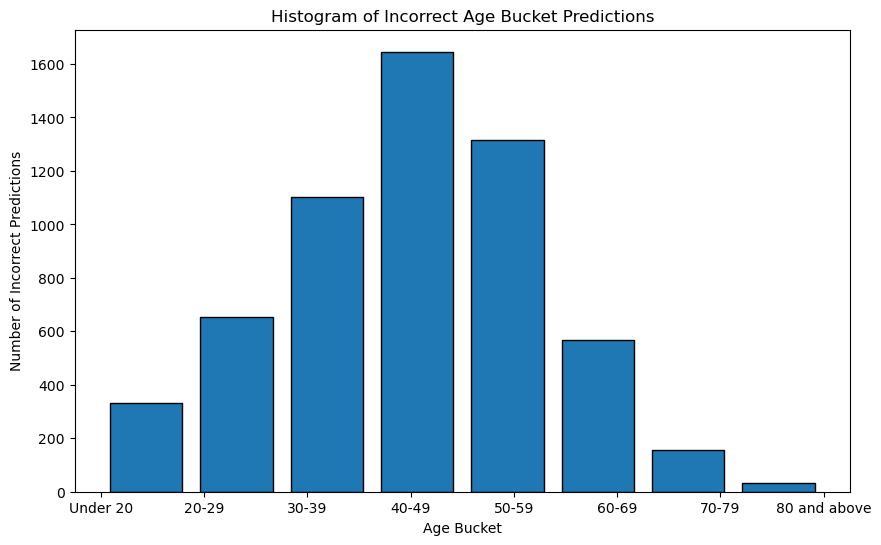

```python
predictions_pd = predictions.toPandas()

incorrect_predictions = predictions_pd[predictions_pd['age_bucket'] != predictions_pd['prediction']]

plt.figure(figsize=(10, 6))
plt.hist(incorrect_predictions['age_bucket'], bins=len(splits)-1, edgecolor='black',
         rwidth=0.8, align='mid')
plt.title('Histogram of Incorrect Age Bucket Predictions')
plt.xlabel('Age Bucket')
plt.ylabel('Number of Incorrect Predictions')
plt.xticks(np.arange(len(splits)-1), age_bucket_labels)
plt.show()
```

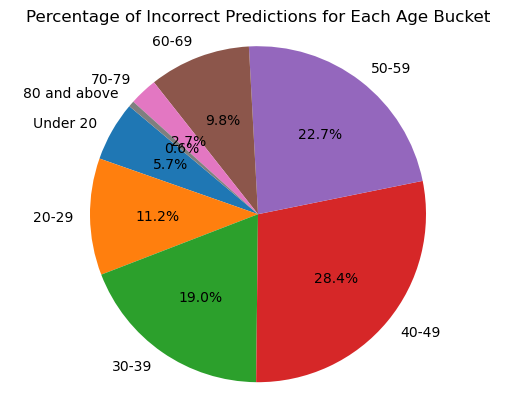

```python
bucket_counts = incorrect_predictions['age_bucket'].value_counts().sort_index()

fig, ax = plt.subplots()
ax.pie(bucket_counts, labels=age_bucket_labels, autopct='%1.1f%%', startangle=140)
ax.axis('equal')
plt.title('Percentage of Incorrect Predictions for Each Age Bucket')
plt.show()
```

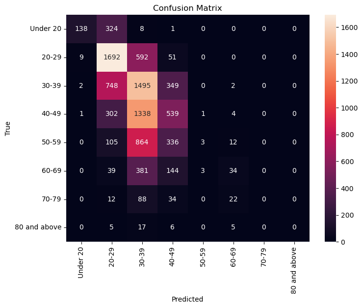

```python
# Was throwing error this fixed.
predictions = predictions.withColumn("prediction", col("prediction").cast("double"))
predictions_and_labels = predictions.select("prediction", "age_bucket").rdd
metrics = MulticlassMetrics(predictions_and_labels)
confusion_matrix = metrics.confusionMatrix()

confusion_matrix_np = confusion_matrix.toArray()
plt.figure(figsize=(8, 6))
sns.heatmap(confusion_matrix_np, annot=True, fmt=".0f",
            xticklabels=age_bucket_labels,
            yticklabels=age_bucket_labels)
plt.xlabel('Predicted')
plt.ylabel('True')
plt.title('Confusion Matrix')
plt.show()
```

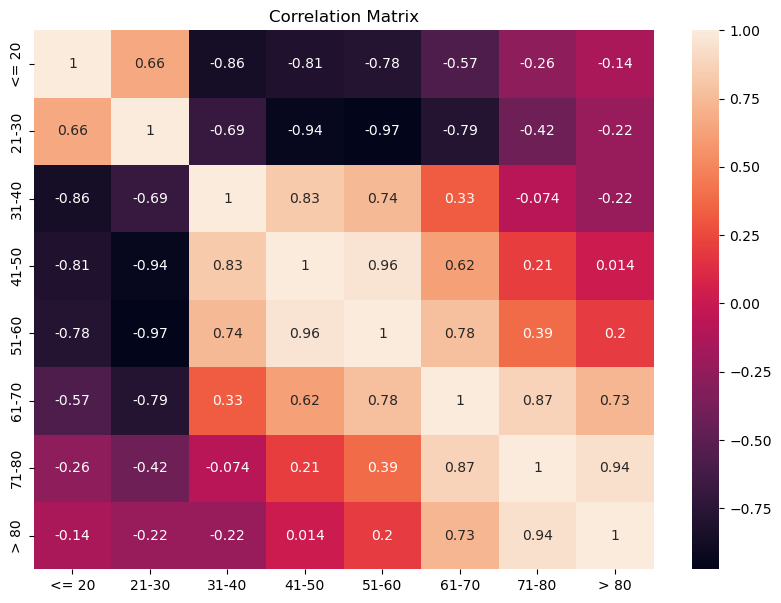

```python
probabilities = predictions.select("probability")
# Define the bucket labels based on age ranges
bucket_labels = ["<= 20", "21-30", "31-40", "41-50", "51-60", "61-70", "71-80", "> 80"]
# Convert probabilities to feature vector
assembler = VectorAssembler(inputCols=probabilities.columns, outputCol="features")
assembled_data = assembler.transform(probabilities).select("features")
correlation_matrix = Correlation.corr(assembled_data, "features").collect()[0][0].toArray()
# Plot correlation matrix with bucket labels
plt.figure(figsize=(10, 7))
sns.heatmap(correlation_matrix, annot=True, xticklabels=bucket_labels, yticklabels=bucket_labels)
plt.title("Correlation Matrix")
plt.show()
```

`There is a substantial improvement from our previous attempt. Shortening the cardinality and the multi-class range helps the model to improve predictive power. It is still far from a good prediction as the accuracy is close to 40%.`

`At this point, the confusion matrix shows that age bucketed could be improved as we are still getting many age buckets at 0. Thinking out of the box, we can then consider a more realistic approach to buckets and divide ages in groups. It may be overfitting but it is a realistic scenario`

## => `Age Prediction Into Age Groups`

Again, we are going to use the RandomForestClassifier algorithm as random forests is an ensemble of decision trees, it can capture non-linear patterns without the need for complex feature engineering.

```python
#let's start from the raw data
temp_data = spark.read.csv(
    "adult.csv",
    escape='"',
    header=True,
    inferSchema=True,
)
splits = [0, 30, 60, float('inf')]
bucketizer = Bucketizer(splits=splits, inputCol="age", outputCol="age_bucket")
data_with_buckets = bucketizer.transform(temp_data)
```

```python
# print data with buckets schema
data_with_buckets.printSchema()
```

```
root
 |-- age: integer (nullable = true)
 |-- workclass: string (nullable = true)
 |-- fnlwgt: integer (nullable = true)
 |-- education: string (nullable = true)
 |-- educational-num: integer (nullable = true)
 |-- marital-status: string (nullable = true)
 |-- occupation: string (nullable = true)
 |-- relationship: string (nullable = true)
 |-- race: string (nullable = true)
 |-- gender: string (nullable = true)
 |-- capital-gain: integer (nullable = true)
 |-- capital-loss: integer (nullable = true)
 |-- hours-per-week: integer (nullable = true)
 |-- native-country: string (nullable = true)
 |-- income: string (nullable = true)
 |-- age_bucket: double (nullable = true)
```

```python
# building less noisy data
categorical_columns = ["marital-status", "occupation", "workclass", "relationship", "race", "native-country", "education"]
for column in categorical_columns:
    string_indexer = StringIndexer(inputCol=column, outputCol=f"{column}_index")
    data_with_buckets = string_indexer.fit(data_with_buckets).transform(data_with_buckets)
data_with_features = data_with_buckets.withColumn("net_capital", col("capital-gain") - col("capital-loss"))
```

```python
# building out the features.
indexed_columns = [f"{column}_index" for column in categorical_columns]
assembler = VectorAssembler(inputCols=indexed_columns + ["net_capital"], outputCol="features")
data_with_features = assembler.transform(data_with_features)
```

```python
# Balance out the data by oversampling the minority class
age_bucket_counts = data_with_features.groupBy("age_bucket").count().collect()
max_count = max([row['count'] for row in age_bucket_counts])
balanced_data = data_with_features
for row in age_bucket_counts:
    factor = max_count // row['count']
    oversampled_data = data_with_features.filter(col("age_bucket")\
        == row['age_bucket'])\
        .withColumn("dummy", lit(1))\
        .drop("dummy")
    balanced_data = balanced_data.unionAll(oversampled_data)
print("Balanced data count: ", balanced_data.count())
```

```
Balanced data count:  97684
```

```python
# Train the model
train_data, test_data = balanced_data.randomSplit([0.8, 0.2], seed=42)
max_categories = max(data_with_features.select(*indexed_columns).distinct().count() for _ in indexed_columns)
rf_classifier = RandomForestClassifier(labelCol="age_bucket", featuresCol="features", maxBins=max_categories + 1)

paramGrid = ParamGridBuilder() \
    .addGrid(rf_classifier.numTrees, [20, 25, 30])\
    .addGrid(rf_classifier.maxDepth, [6, 9, 12])\
    .addGrid(rf_classifier.minInfoGain, [0.0, 0.1, 0.2])\
    .build()

crossval = CrossValidator(estimator=rf_classifier,
                          estimatorParamMaps=paramGrid,
                          evaluator=MulticlassClassificationEvaluator(labelCol="age_bucket"),
                          numFolds=2)
cvModel = crossval.fit(train_data)
predictions = cvModel.transform(test_data)
```

```python
# evaluate model
evaluator = MulticlassClassificationEvaluator(labelCol="age_bucket", predictionCol="prediction")
accuracy = evaluator.evaluate(predictions, {evaluator.metricName: "accuracy"})
precision = evaluator.evaluate(predictions, {evaluator.metricName: "weightedPrecision"})
recall = evaluator.evaluate(predictions, {evaluator.metricName: "weightedRecall"})
f1 = evaluator.evaluate(predictions, {evaluator.metricName: "f1"})

# print scores.
print(f"Accuracy: {accuracy}")
print(f"Precision: {precision}")
print(f"Recall: {recall}")
print(f"F1 Score: {f1}")
```

```
[Stage 1270:===================================>                    (5 + 3) / 8]
```

```
Accuracy: 0.7787179487179487
Precision: 0.7725521502070767
Recall: 0.7787179487179487
F1 Score: 0.7660221314929344
```

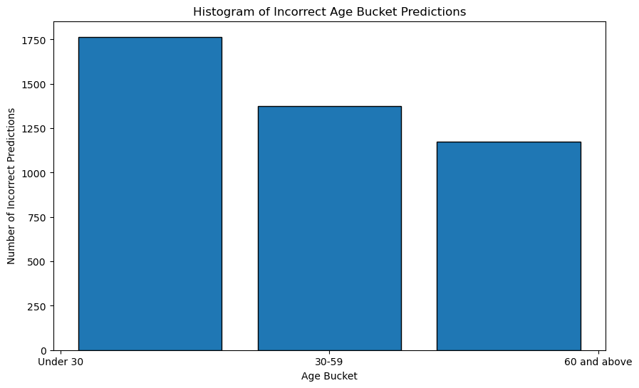

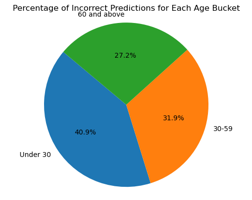

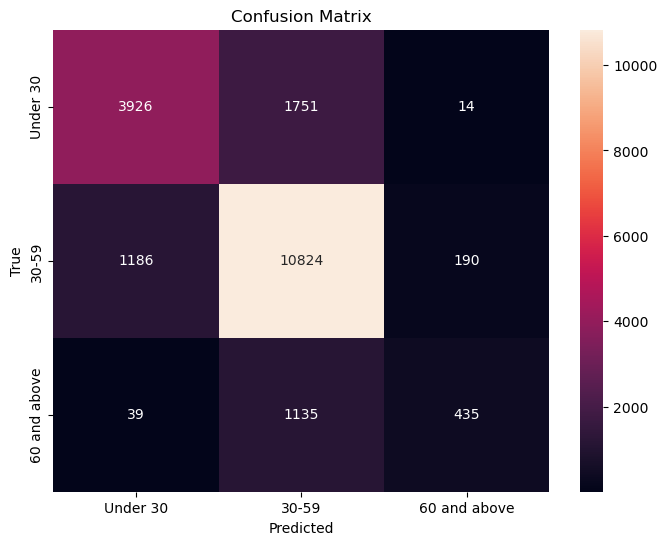

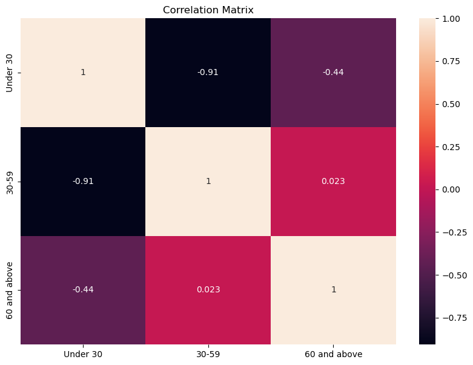

```python
#  age bucket labels
age_bucket_labels = [
    "Under 30",     # 0: -inf to 29
    "30-59",        # 1: 30 to 59
    "60 and above"  # 2: 60 to inf
]
predictions_pd = predictions.toPandas()

incorrect_predictions = predictions_pd[predictions_pd['age_bucket'] != predictions_pd['prediction']]

plt.figure(figsize=(10, 6))
plt.hist(incorrect_predictions['age_bucket'], bins=len(splits)-1, edgecolor='black',
         rwidth=0.8, align='mid')
plt.title('Histogram of Incorrect Age Bucket Predictions')
plt.xlabel('Age Bucket')
plt.ylabel('Number of Incorrect Predictions')
plt.xticks(np.arange(len(splits)-1), age_bucket_labels)
plt.show()
bucket_counts = incorrect_predictions['age_bucket'].value_counts().sort_index()

fig, ax = plt.subplots()
ax.pie(bucket_counts, labels=age_bucket_labels, autopct='%1.1f%%', startangle=140)
ax.axis('equal')
plt.title('Percentage of Incorrect Predictions for Each Age Bucket')
plt.show()

# Was throwing error this fixed.
predictions = predictions.withColumn("prediction", col("prediction").cast("double"))
predictions_and_labels = predictions.select("prediction", "age_bucket").rdd
metrics = MulticlassMetrics(predictions_and_labels)
confusion_matrix = metrics.confusionMatrix()

confusion_matrix_np = confusion_matrix.toArray()
plt.figure(figsize=(8, 6))
sns.heatmap(confusion_matrix_np, annot=True, fmt=".0f",
            xticklabels=age_bucket_labels,
            yticklabels=age_bucket_labels)
plt.xlabel('Predicted')
plt.ylabel('True')
plt.title('Confusion Matrix')
plt.show()
probabilities = predictions.select("probability")
# Define the bucket labels based on age ranges
bucket_labels = age_bucket_labels
# Convert probabilities to feature vector
assembler = VectorAssembler(inputCols=probabilities.columns, outputCol="features")
assembled_data = assembler.transform(probabilities).select("features")
correlation_matrix = Correlation.corr(assembled_data, "features").collect()[0][0].toArray()
# Plot correlation matrix.
plt.figure(figsize=(10, 7))
sns.heatmap(correlation_matrix, annot=True, xticklabels=bucket_labels, yticklabels=bucket_labels)
plt.title("Correlation Matrix")
plt.show()
```

`Let's now consider another multi-class feature, like the marital status. We can consider predicting from the marital status, which is another featured column that is also a multi-class field. Perhaps we can obtain a better prediction as features may have a higher correlation; although we will use an algorithm that can also better capture non-linear patterns.`

## => `Predict marital status`

We will use RandomForestClassifier as it provides a built-in method for determining feature importance and since random forests is an ensemble of decision trees, it can capture these non-linear patterns without the need for complex feature engineering.

For the marital-status we will need to convert the multi-class categorical value to numeric indexes as it is not natively supported by the algorithm.

### Prepare and analyze data

```
+-------+--------------+
|summary|marital_status|
+-------+--------------+
|  count|         48842|
|   mean|          null|
| stddev|          null|
|    min|      Divorced|
|    max|       Widowed|
+-------+--------------+

+--------------------+-----+
|      marital_status|count|
+--------------------+-----+
|           Separated| 1530|
|       Never-married|16117|
|Married-spouse-ab...|  628|
|            Divorced| 6633|
|             Widowed| 1518|
|   Married-AF-spouse|   37|
|  Married-civ-spouse|22379|
+--------------------+-----+
```

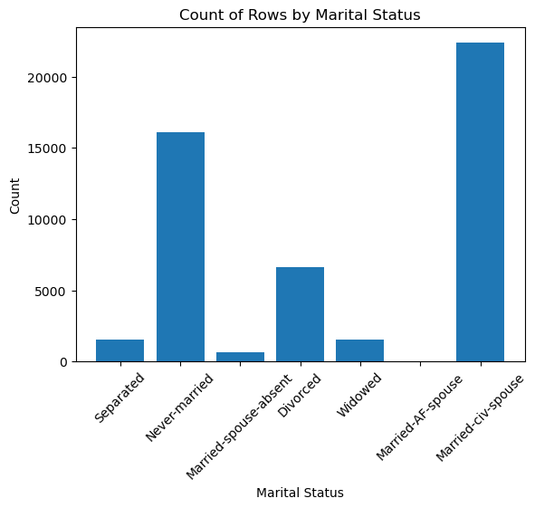

```python
#let's start clean
data = raw_data

# drop as we already have capital gain/loss and hours-per-week
data = data.drop("fnlwgt")

numerical = []
strings = []

# Need to rename columns for SQL compatibility
for col, dtype in data.dtypes:
    data = data.withColumnRenamed(col, col.replace("-", "_"))

# separate columns into string or numerical features.
for col, dtype in data.dtypes:
    if dtype in ["string"]:
        strings.append(col)
    else:
        numerical.append(col)

#describe the data to understand statistics
data.describe("marital_status").show()

# Group by 'marital_status' and count the number of occurrences
grouped_df = data.groupBy("marital_status").agg(F.count("marital_status").alias("count"))
# Convert grouped DataFrame to Pandas
grouped_pd = grouped_df.toPandas()
grouped_df.show()

# Plot
plt.bar(grouped_pd['marital_status'], grouped_pd['count'])
plt.xlabel('Marital Status')
plt.ylabel('Count')
plt.title('Count of Rows by Marital Status')
plt.xticks(rotation=45)  # Rotate x-axis labels for better readability
plt.show()
```

`We can observe that the majority of the data is allocated in two classes: Married-civ-spouse, and Never-Married.`

### Feature Engineering

Even though we've addressed missing values before, we will now fill any remaining gaps with the respective column's minimum value to minimize potential data skew. The process is not really needed in this particular case, but it shows a viable alternative using SQLTransformer.

```python
# Martial Status
binary = False
target = "marital_status"

target_index = f"{target}_index"

imputed_stages = []

for col in strings:
    min = data.filter(data[col] != '?').groupBy(col).count().orderBy('count', ascending=True).first()[0]

    sqlTrans = SQLTransformer(
        statement=f"""
        SELECT *,
        CASE WHEN {col} = '?' THEN True ELSE False END AS {col}_is_missing,
        CASE WHEN {col} = '?' THEN '{min}' ELSE {col} END AS {col}_imputed
        FROM __THIS__
        """)

    imputed_stages.append(sqlTrans)

string_indexers = [StringIndexer(inputCol=f"{col}_imputed", outputCol=f"{col}_index") for col in strings]

one_hot_encoders = [OneHotEncoder(inputCol=f"{col}_index", outputCol=f"{col}_vec") for col in strings]

features = [f"{col}_vec" for col in strings if col != target] + [f"{col}_is_missing" for col in strings if col != target] + [x for x in numerical if x != "educational_num"]

assembler = VectorAssembler(inputCols=features, outputCol="feature_vector")

scaler = StandardScaler(inputCol="feature_vector", outputCol="scaled_features",
                        withStd=True, withMean=True)

pipeline = Pipeline(stages=imputed_stages + string_indexers + one_hot_encoders + [assembler, scaler])


data = pipeline.fit(data).transform(data)
```

### Peform stratified sampling

performing stratified sampling on the data DataFrame to split it into training and testing sets. It ensures that both sets have a similar distribution of the target_index column values by sampling 80% of each distinct value for the training set and leaving the rest for the test set.

```python
fractions = data.select(target_index).distinct().withColumn("fraction", F.lit(0.8)).rdd.collectAsMap()
train_df = data.stat.sampleBy(target_index, fractions, seed=42)
test_df = data.subtract(train_df)
```

### Train and explore ML algorithms models

```python
if binary:
    trainer = GBTClassifier(labelCol=target_index, featuresCol="scaled_features", maxIter=10)
else:
    trainer = RandomForestClassifier(labelCol=target_index, featuresCol="scaled_features")

model = trainer.fit(train_df)
predictions = model.transform(test_df)
```

### Prediction Metrics & Visualization

```
Accuracy:  0.7492685408981046
Weighted Precision:  0.6704919504074861
Weighted Recall:  0.7492685408981046
F1 Score:  0.6885212341658764
```

[figure not shown]

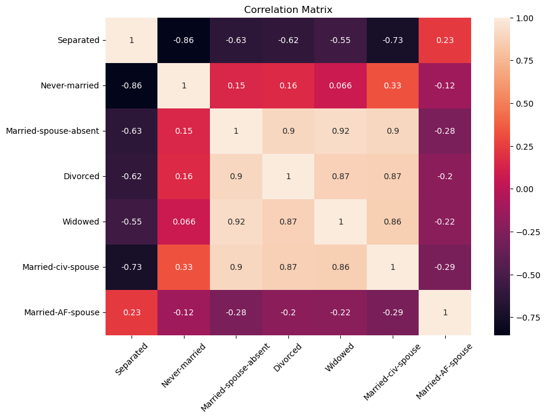

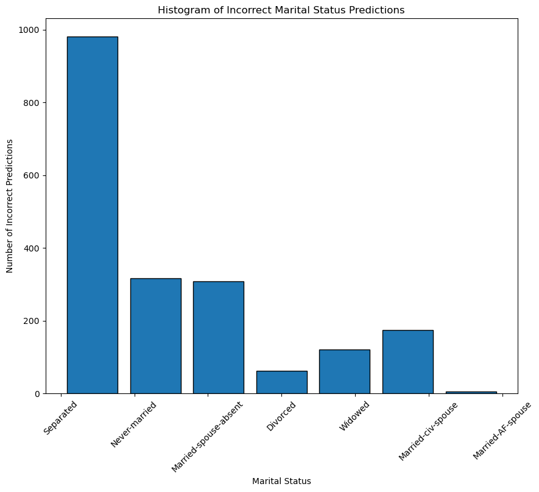

```python
accuracy_evaluator = MulticlassClassificationEvaluator(labelCol=target_index, predictionCol="prediction", metricName="accuracy")
precision_evaluator = MulticlassClassificationEvaluator(labelCol=target_index, predictionCol="prediction", metricName="weightedPrecision")
recall_evaluator = MulticlassClassificationEvaluator(labelCol=target_index, predictionCol="prediction", metricName="weightedRecall")
f1_evaluator = MulticlassClassificationEvaluator(labelCol=target_index, predictionCol="prediction", metricName="f1")

accuracy = accuracy_evaluator.evaluate(predictions)
precision = precision_evaluator.evaluate(predictions)
recall = recall_evaluator.evaluate(predictions)
f1_score = f1_evaluator.evaluate(predictions)
reg_evaluator = RegressionEvaluator(labelCol="marital_status_index", predictionCol="prediction", metricName="rmse")

# Print metrics
print("Accuracy: ", accuracy)
print("Weighted Precision: ", precision)
print("Weighted Recall: ", recall)
print("F1 Score: ", f1_score)

# Extract unique marital_status values into a list
graph_labels = [row['marital_status'] for row in predictions.select('marital_status').distinct().collect()]


metrics = MulticlassMetrics(predictions.select('prediction', target_index).rdd)
confusion_matrix = metrics.confusionMatrix().toArray()

plt.figure(figsize=(10, 7))
ax = sns.heatmap(confusion_matrix, annot=True, fmt=".0f", xticklabels=graph_labels, yticklabels=graph_labels)
ax.set_xticklabels(ax.get_xticklabels(), rotation=45)
plt.xlabel('Predicted')
plt.ylabel('Actual')
plt.title("Confusion Matrix")
plt.show()


# Correlation matrix
probabilities = predictions.select("probability")

# Convert probabilities to feature vector
assembler = VectorAssembler(inputCols=probabilities.columns, outputCol="features")
assembled_data = assembler.transform(probabilities).select("features")
correlation_matrix = Correlation.corr(assembled_data, "features").collect()[0][0].toArray()
# Plot correlation matrix with bucket labels
plt.figure(figsize=(10, 7))
ax = sns.heatmap(correlation_matrix, annot=True, xticklabels=graph_labels, yticklabels=graph_labels)
ax.set_xticklabels(ax.get_xticklabels(), rotation=45)
plt.title("Correlation Matrix")
plt.show()

#histogram
predictions_pd = predictions.toPandas()

incorrect_predictions = predictions_pd[predictions_pd['marital_status_index'] != predictions_pd['prediction']]

plt.figure(figsize=(10, 8))
plt.hist(incorrect_predictions['marital_status'], bins=len(graph_labels), edgecolor='black',
         rwidth=0.8, align='mid')
plt.title('Histogram of Incorrect Marital Status Predictions')
plt.xlabel('Marital Status')
plt.ylabel('Number of Incorrect Predictions')
plt.xticks(np.arange(len(graph_labels)), graph_labels, rotation=45)
plt.show()
```

`On the whole, the model seems to adequately predict marital status. Yet, it's crucial to note that the data is predominantly composed of two classes: Married-civ-spouse and Never-Married. As a result, the model might struggle to accurately predict the less-represented classes. Thus, while overall performance metrics may be encouraging, a class-by-class evaluation reveals significant prediction disparities.`

## `Limitations`

1. **Model Generality**: Our model may overfit to the specific patterns and noises in our dataset. This could lead to high performance on our training set but a potential decrease in performance on new, unseen data.
2. **Feature Engineering Bias**: While feature engineering can uncover hidden relationships, it's also prone to human biases. Our choices in combining or creating new features are based on our domain knowledge and assumptions, which may not always hold true.
3. **Computational Constraints**: Hyperparameter optimization, especially using exhaustive methods like grid search, can be computationally expensive and time-consuming. Without adequate resources, we might miss the best parameter combinations.
4. **Data Limitations**: Despite emphasizing data quality, our dataset might still have hidden biases or missing important features which could lead to biased or suboptimal predictions.

## `Future Work`

1. **Model Ensembling**: Combining predictions from multiple models can often lead to better results than any single model on its own. Techniques like stacking or boosting could be explored.
2. **Deep Learning**: Neural networks and deep learning methods might be able to capture complex non-linear relationships in the data that traditional machine learning models might miss.
3. **Incorporate External Data**: Bringing in supplementary data sources or leveraging domain-specific knowledge could enhance our feature set and potentially improve predictions.
4. **Real-time Learning**: If data is continuously being generated, models that can learn in real-time or adapt to new data on-the-fly might prove beneficial.

## `Conclusion`

In our exploration, we've realized the significant role of data quality, feature engineering, and model optimization in predictive modeling. While we achieved notable results with our current approach, the journey of data science is iterative and ever-evolving. As we've identified potential limitations and avenues for future work, it's evident that there's always room for improvement and innovation. Embracing a holistic approach, which balances domain knowledge, computational techniques, and rigorous validation, will guide us towards even more accurate and robust models in the future.